# Zunqiu_Wang_ngs_wk12_hw

Zunqiu Wang

4/17/2021

# Task 1: MACS2 peaks and FRiP scores

Q1.1a: How many peaks were called by MACS2 for each of the two Androgren Receptor ChIP-Seq samples in your MACS2 outputs from last week?

```bash
wc -l SRR7207017_peaks.narrowPeak
20783 SRR7207017_peaks.narrowPeak
wc -l SRR7207011_peaks.narrowPeak
2001 SRR7207011_peaks.narrowPeak
```

Q1.1b: What is the mean peak width for each sample? Show the R command (or other approach) you used to arrive at your answer.

```r
SRR7207017.df <- read.table("SRR7207017_peaks.narrowPeak", header = F, sep = "\t", stringsAsFactors = F)
SRR7207017.df$width <- SRR7207017.df$V3-SRR7207017.df$V2
SRR7207017.mean <- mean(SRR7207017.df$width)
SRR7207017.mean
```

```
## [1] 337.2638
```

```r
SRR7207011.df <- read.table("SRR7207011_peaks.narrowPeak", header = F, sep = "\t", stringsAsFactors = F)
SRR7207011.df$width <- SRR7207011.df$V3-SRR7207011.df$V2
SRR7207011.mean <- mean(SRR7207011.df$width)
SRR7207011.mean
```

```
## [1] 255.7596
```

Q1.1c: What is meant by the “signalValue” in column 7?

- Measurement of overall (usually, average) enrichment for the region.

Q1.2. The Fraction of Reads in Peaks (FRiP) score is a simple measure of library quality that is useful in identifying low-quality libraries from a set of ChIP-seq libraries (i.e., it is useful in a comparative context). The FRiP score is calculated as implied by the name and is simply the number of reads overlapping called peaks divided by the total number of reads.

```bash
module load bedtools/intel/2.29.2
bedtools intersect -a /scratch/zw2946/ngs.week11/task3/SRR7207011/SRR7207011.filtered.sorted.bam -b /scratch/zw2946/ngs.week11/task4/SRR7207011_peaks.narrowPeak | wc -l
69002
module load samtools/intel/1.12
samtools view -c /scratch/zw2946/ngs.week11/task3/SRR7207011/SRR7207011.filtered.sorted.bam
22517898
```

- 69002/22517898=0.003064318

```bash
bedtools intersect -a /scratch/zw2946/ngs.week11/task3/SRR7207017/SRR7207017.filtered.sorted.bam -b /scratch/zw2946/ngs.week11/task4/SRR7207017_peaks.narrowPeak | wc -l
877004
samtools view -c /scratch/zw2946/ngs.week11/task3/SRR7207017/SRR7207017.filtered.sorted.bam
20702991
```

- 877004/20702991=0.04236122
- SRR7207017 passed
- SRR7207011 fail to pass

# Task 2: QC analysis of H3K36me3 ChIP-seq with the BioConductor ChIC package

Q2.1a.Include the cross-corrleation profile plot in your answers file [ 1 point ].

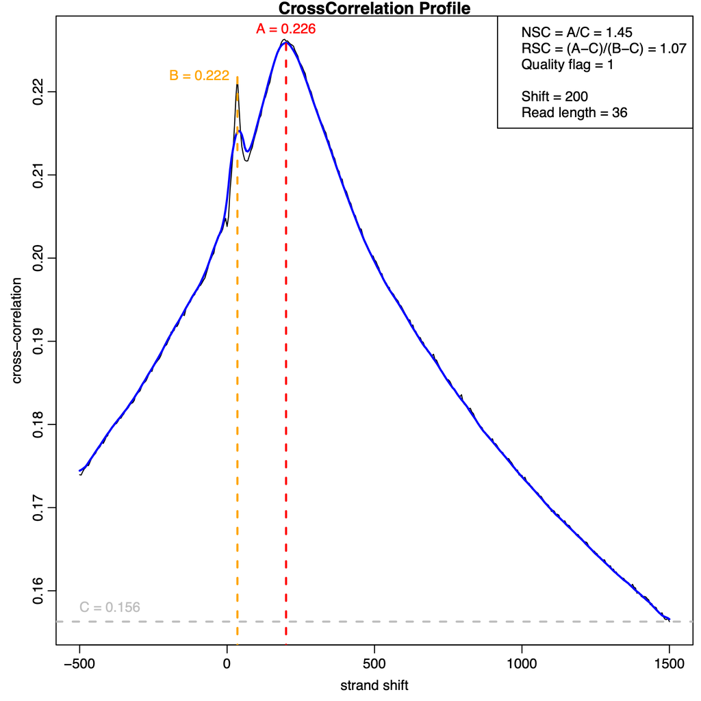

Cross Correlation of Chip Sample

Q2.1b Select all that are true statements about the cross-correlation profile [ 1 point ]:

- b d f

Q2.2a What is the NSC value for the ChIP sample?

- 1.447

Q2.2b What is the RSC values for the ChIP sample?

- 1.065

Q2.2c Do either of the metrics incorporate the “shaddow peak” height in how they are calculated? Which one(s)?

- yes, phantom pick was incorporated in RSC

Q2.2d Landt et al. 2012 (see “Cross-correlation Analysis”) provide minimum NSC and RSC values for libraries with acceptable signal-to-noise ratios. What are these minimum values and does this library pass ENCODE standards for quality control? Select one:

- f

Q2.3 Now answer the following for the input sample. Be sure to include the cross-correlation profile figure for the input sample in your answer [ 1 point ].

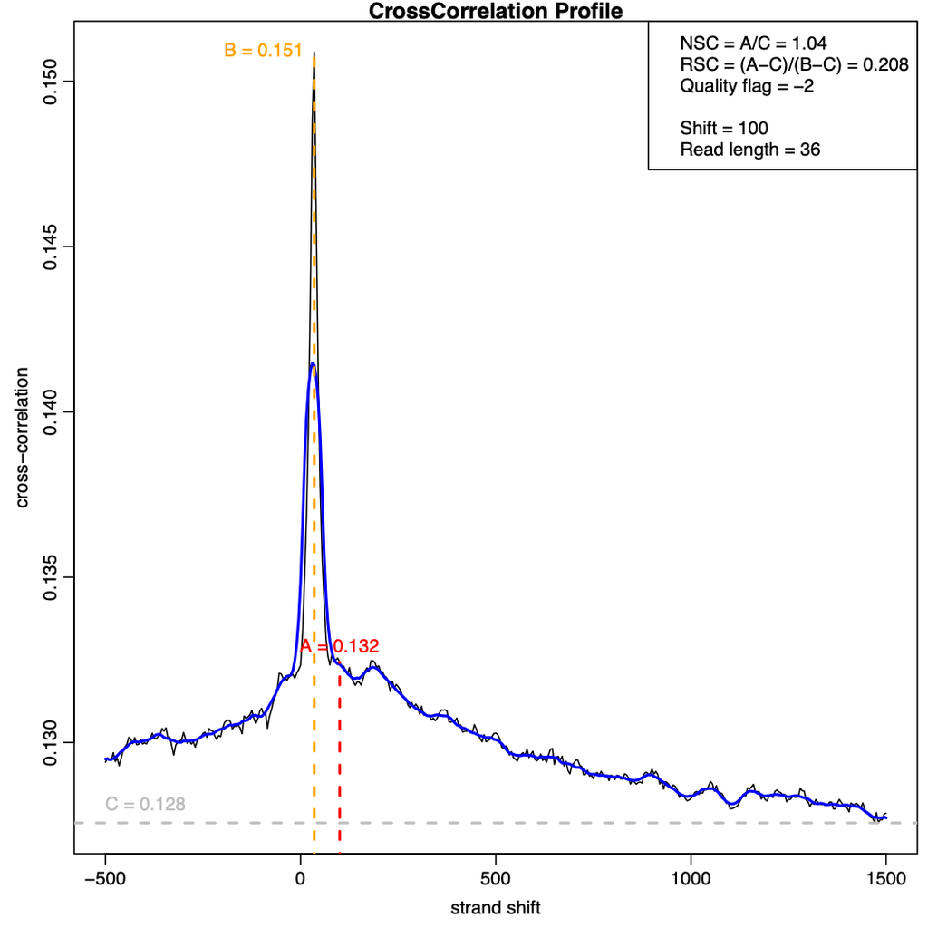

Cross Correlation of input

Q2.3a What steps are typically included/excluded in the preparation of the control/input sample? (see Week 11 pre-recorded video). Select all true statements.

- includes a,b,d,e
- excludes c

Q2.3b What are the NSC and RSC values for the input sample? Would this library pass the quality control standards for the ENCODE project if it were a ChIP sample?

- NSC:1.038
- RSC:0.208
- No, both values fall under threshold

- b

Q2.5. What is shown in the TSS plot? Please provide a detailed interpretation of the plot. Based on the TSS profile plot, describe where are H3K36me3 modifications typically located relative to protein coding genes. [ 1 point ]